# Statistical Anomaly Detection

```python
import pandas as pd
import numpy as np
import matplotlib.pyplot as plt
```

```python
monthly = pd.read_csv("monthly_demand_clean_long.csv",parse_dates=["OrderDate"])
monthly.head()                                                                           ## Load the Clean Dataset
```

|  | OrderDate | CategoryName | Quantity |
| --- | --- | --- | --- |
| 0 | 2013-06-01 | CPU | NaN |
| 1 | 2013-07-01 | CPU | NaN |
| 2 | 2013-08-01 | CPU | NaN |
| 3 | 2013-09-01 | CPU | NaN |
| 4 | 2013-10-01 | CPU | NaN |

```python
monthly.info()                                                                           ## Check Dataset Information
```

```
<class 'pandas.core.frame.DataFrame'>
RangeIndex: 270 entries, 0 to 269
Data columns (total 3 columns):
 #   Column        Non-Null Count  Dtype
---  ------        --------------  -----
 0   OrderDate     270 non-null    datetime64[ns]
 1   CategoryName  270 non-null    object
 2   Quantity      174 non-null    float64
dtypes: datetime64[ns](1), float64(1), object(1)
memory usage: 6.5+ KB
```

```python
monthly.isnull().sum()                                                               ## Check Null Values
```

```
OrderDate        0
CategoryName     0
Quantity        96
dtype: int64
```

```python
monthly[monthly["Quantity"].isnull()].head(10)
```

|  | OrderDate | CategoryName | Quantity |
| --- | --- | --- | --- |
| 0 | 2013-06-01 | CPU | NaN |
| 1 | 2013-07-01 | CPU | NaN |
| 2 | 2013-08-01 | CPU | NaN |
| 3 | 2013-09-01 | CPU | NaN |
| 4 | 2013-10-01 | CPU | NaN |
| 5 | 2013-11-01 | CPU | NaN |
| 6 | 2013-12-01 | CPU | NaN |
| 7 | 2014-01-01 | CPU | NaN |
| 8 | 2014-02-01 | CPU | NaN |
| 9 | 2014-03-01 | CPU | NaN |

```python
monthly["Quantity"] = monthly["Quantity"].fillna(0)                                   ## Remove null
```

```python
monthly.isnull().sum()
```

```
OrderDate       0
CategoryName    0
Quantity        0
dtype: int64
```

```python
monthly.describe()                                                            ## Check Dataset Statistics
```

|  | OrderDate | Quantity |
| --- | --- | --- |
| count | 270 | 270.000000 |
| mean | 2015-08-16 17:20:00 | 62.322222 |
| min | 2013-06-01 00:00:00 | 0.000000 |
| 25% | 2014-07-01 00:00:00 | 0.000000 |
| 50% | 2015-08-16 12:00:00 | 0.000000 |
| 75% | 2016-10-01 00:00:00 | 76.000000 |
| max | 2017-11-01 00:00:00 | 870.000000 |
| std | NaN | 125.506631 |

```python
monthly["CategoryName"].value_counts()                                          ## Count Records by Product Category
```

```
CategoryName
CPU             54
Mother Board    54
RAM             54
Storage         54
Video Card      54
Name: count, dtype: int64
```

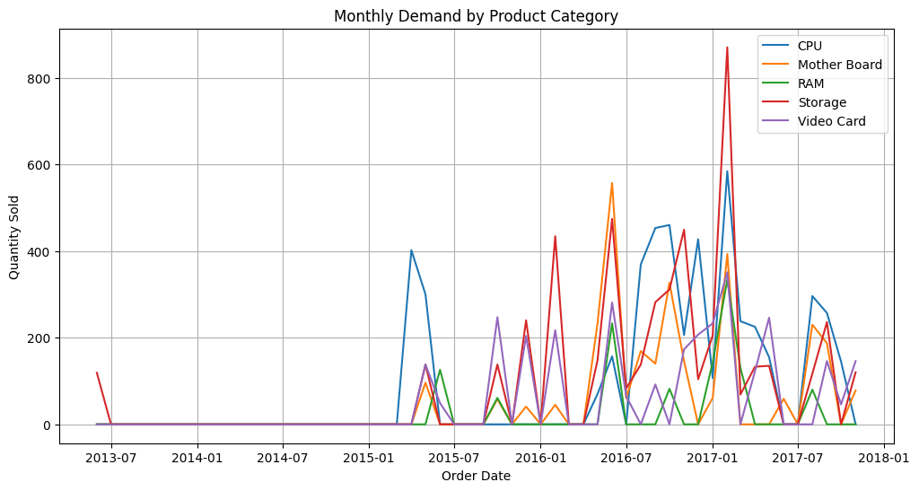

```python
plt.figure(figsize=(12,6))                                                       ## Plot Demand Trends

for category in monthly["CategoryName"].unique():
    data = monthly[monthly["CategoryName"] == category]
    plt.plot(
        data["OrderDate"],
        data["Quantity"],
        label=category
    )

plt.title("Monthly Demand by Product Category")
plt.xlabel("Order Date")
plt.ylabel("Quantity Sold")
plt.legend()
plt.grid(True)

plt.savefig(
    "monthly_demand_trend.png",
    dpi=300,
    bbox_inches="tight"
)

plt.show()
```

### Z-Score Anomaly Detection for Each Product Category

```python
from scipy.stats import zscore
```

```python
monthly.head()                                                     ## Checking dataset before calculation
```

|  | OrderDate | CategoryName | Quantity |
| --- | --- | --- | --- |
| 0 | 2013-06-01 | CPU | 0.0 |
| 1 | 2013-07-01 | CPU | 0.0 |
| 2 | 2013-08-01 | CPU | 0.0 |
| 3 | 2013-09-01 | CPU | 0.0 |
| 4 | 2013-10-01 | CPU | 0.0 |

```python
monthly.columns
```

```
Index(['OrderDate', 'CategoryName', 'Quantity'], dtype='object')
```

```python
monthly["CategoryName"].unique()
```

```
array(['CPU', 'Mother Board', 'RAM', 'Storage', 'Video Card'],
      dtype=object)
```

```python
monthly["ZScore"] = (monthly.groupby("CategoryName")["Quantity"]                 ## Calculating Z-Score for each product category
    .transform(lambda x: zscore(x, nan_policy="omit")))
monthly.head(10)
```

|  | OrderDate | CategoryName | Quantity | ZScore |
| --- | --- | --- | --- | --- |
| 0 | 2013-06-01 | CPU | 0.0 | -0.583121 |
| 1 | 2013-07-01 | CPU | 0.0 | -0.583121 |
| 2 | 2013-08-01 | CPU | 0.0 | -0.583121 |
| 3 | 2013-09-01 | CPU | 0.0 | -0.583121 |
| 4 | 2013-10-01 | CPU | 0.0 | -0.583121 |
| 5 | 2013-11-01 | CPU | 0.0 | -0.583121 |
| 6 | 2013-12-01 | CPU | 0.0 | -0.583121 |
| 7 | 2014-01-01 | CPU | 0.0 | -0.583121 |
| 8 | 2014-02-01 | CPU | 0.0 | -0.583121 |
| 9 | 2014-03-01 | CPU | 0.0 | -0.583121 |

```python
monthly[["OrderDate", "CategoryName", "Quantity", "ZScore"]].head(10)              ## Check the Z-Score values
```

|  | OrderDate | CategoryName | Quantity | ZScore |
| --- | --- | --- | --- | --- |
| 0 | 2013-06-01 | CPU | 0.0 | -0.583121 |
| 1 | 2013-07-01 | CPU | 0.0 | -0.583121 |
| 2 | 2013-08-01 | CPU | 0.0 | -0.583121 |
| 3 | 2013-09-01 | CPU | 0.0 | -0.583121 |
| 4 | 2013-10-01 | CPU | 0.0 | -0.583121 |
| 5 | 2013-11-01 | CPU | 0.0 | -0.583121 |
| 6 | 2013-12-01 | CPU | 0.0 | -0.583121 |
| 7 | 2014-01-01 | CPU | 0.0 | -0.583121 |
| 8 | 2014-02-01 | CPU | 0.0 | -0.583121 |
| 9 | 2014-03-01 | CPU | 0.0 | -0.583121 |

```python
monthly.loc[
    monthly["ZScore"].abs().sort_values(ascending=False).index,
    ["OrderDate", "CategoryName", "Quantity", "ZScore"]].head(10)
```

|  | OrderDate | CategoryName | Quantity | ZScore |
| --- | --- | --- | --- | --- |
| 152 | 2017-02-01 | RAM | 334.0 | 5.005993 |
| 206 | 2017-02-01 | Storage | 870.0 | 4.783234 |
| 90 | 2016-06-01 | Mother Board | 557.0 | 4.546087 |
| 144 | 2016-06-01 | RAM | 233.0 | 3.385367 |
| 44 | 2017-02-01 | CPU | 584.0 | 3.207708 |
| 260 | 2017-02-01 | Video Card | 351.0 | 3.171341 |
| 98 | 2017-02-01 | Mother Board | 393.0 | 3.065825 |
| 94 | 2016-10-01 | Mother Board | 327.0 | 2.470111 |
| 252 | 2016-06-01 | Video Card | 281.0 | 2.421643 |
| 40 | 2016-10-01 | CPU | 460.0 | 2.402806 |

```python
monthly.groupby("CategoryName")["ZScore"].agg(["min", "max"])
```

| CategoryName | min | max |
| --- | --- | --- |
| CPU | -0.583121 | 3.207708 |
| Mother Board | -0.481386 | 4.546087 |
| RAM | -0.353305 | 5.005993 |
| Storage | -0.562446 | 4.783234 |
| Video Card | -0.587858 | 3.171341 |

```python
threshold = 3                                                               ## Define the anomaly threshold
```

```python
monthly["ZScore_Anomaly"] = (monthly["ZScore"].abs() > threshold)
monthly.head()
```

|  | OrderDate | CategoryName | Quantity | ZScore | ZScore_Anomaly |
| --- | --- | --- | --- | --- | --- |
| 0 | 2013-06-01 | CPU | 0.0 | -0.583121 | False |
| 1 | 2013-07-01 | CPU | 0.0 | -0.583121 | False |
| 2 | 2013-08-01 | CPU | 0.0 | -0.583121 | False |
| 3 | 2013-09-01 | CPU | 0.0 | -0.583121 | False |
| 4 | 2013-10-01 | CPU | 0.0 | -0.583121 | False |

```python
zscore_anomalies = monthly[monthly["ZScore_Anomaly"] == True]                                    ## Display only detected anomalies
zscore_anomalies
```

|  | OrderDate | CategoryName | Quantity | ZScore | ZScore_Anomaly |
| --- | --- | --- | --- | --- | --- |
| 44 | 2017-02-01 | CPU | 584.0 | 3.207708 | True |
| 90 | 2016-06-01 | Mother Board | 557.0 | 4.546087 | True |
| 98 | 2017-02-01 | Mother Board | 393.0 | 3.065825 | True |
| 144 | 2016-06-01 | RAM | 233.0 | 3.385367 | True |
| 152 | 2017-02-01 | RAM | 334.0 | 5.005993 | True |
| 206 | 2017-02-01 | Storage | 870.0 | 4.783234 | True |
| 260 | 2017-02-01 | Video Card | 351.0 | 3.171341 | True |

```python
print("Total Z-Score anomalies:",len(zscore_anomalies))
```

```
Total Z-Score anomalies: 7
```

```python
anomaly_counts = (monthly.groupby("CategoryName")["ZScore_Anomaly"].sum())                            ## Count anomalies for each category
anomaly_counts
```

```
CategoryName
CPU             1
Mother Board    2
RAM             2
Storage         1
Video Card      1
Name: ZScore_Anomaly, dtype: int64
```

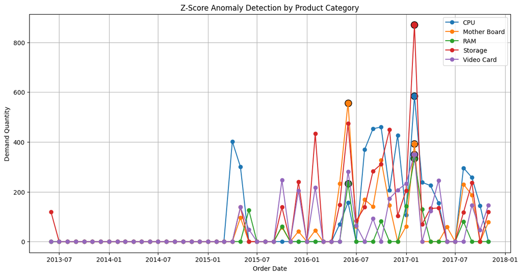

```python
plt.figure(figsize=(14, 7))

for category in monthly["CategoryName"].unique():

    category_data = monthly[
        monthly["CategoryName"] == category]

    plt.plot(
        category_data["OrderDate"],
        category_data["Quantity"],
        marker="o",
        label=category)

    anomaly_data = category_data[
        category_data["ZScore_Anomaly"] == True]

    plt.scatter(
        anomaly_data["OrderDate"],
        anomaly_data["Quantity"],
        s=120,
        edgecolor="black")

plt.title("Z-Score Anomaly Detection by Product Category")
plt.xlabel("Order Date")
plt.ylabel("Demand Quantity")
plt.legend()
plt.grid(True)

plt.savefig(
    "zscore_anomaly_detection.png",
    dpi=300,
    bbox_inches="tight")

plt.show()
```

```python
monthly.to_csv("zscore_anomaly_results.csv",index=False)
```

```python
zscore_anomalies.to_csv("zscore_detected_anomalies.csv",index=False)
```

### IQR Anomaly Detection + Comparison with Z-Score

```python
monthly.head()
```

|  | OrderDate | CategoryName | Quantity | ZScore | ZScore_Anomaly |
| --- | --- | --- | --- | --- | --- |
| 0 | 2013-06-01 | CPU | 0.0 | -0.583121 | False |
| 1 | 2013-07-01 | CPU | 0.0 | -0.583121 | False |
| 2 | 2013-08-01 | CPU | 0.0 | -0.583121 | False |
| 3 | 2013-09-01 | CPU | 0.0 | -0.583121 | False |
| 4 | 2013-10-01 | CPU | 0.0 | -0.583121 | False |

```python
monthly.columns
```

```
Index(['OrderDate', 'CategoryName', 'Quantity', 'ZScore', 'ZScore_Anomaly'], dtype='object')
```

```python
monthly = pd.read_csv("zscore_anomaly_results.csv",parse_dates=["OrderDate"])
monthly.head()
```

|  | OrderDate | CategoryName | Quantity | ZScore | ZScore_Anomaly |
| --- | --- | --- | --- | --- | --- |
| 0 | 2013-06-01 | CPU | 0.0 | -0.583121 | False |
| 1 | 2013-07-01 | CPU | 0.0 | -0.583121 | False |
| 2 | 2013-08-01 | CPU | 0.0 | -0.583121 | False |
| 3 | 2013-09-01 | CPU | 0.0 | -0.583121 | False |
| 4 | 2013-10-01 | CPU | 0.0 | -0.583121 | False |

```python
# Create empty columns
monthly["IQR_Lower"] = np.nan
monthly["IQR_Upper"] = np.nan
monthly["IQR_Anomaly"] = False

# Calculate IQR separately for each product category
for category in monthly["CategoryName"].unique():

    mask = monthly["CategoryName"] == category

    Q1 = monthly.loc[mask, "Quantity"].quantile(0.25)
    Q3 = monthly.loc[mask, "Quantity"].quantile(0.75)

    IQR = Q3 - Q1

    lower_bound = Q1 - 1.5 * IQR
    upper_bound = Q3 + 1.5 * IQR

    monthly.loc[mask, "IQR_Lower"] = lower_bound
    monthly.loc[mask, "IQR_Upper"] = upper_bound

    monthly.loc[mask, "IQR_Anomaly"] = (
        (monthly.loc[mask, "Quantity"] < lower_bound) |
        (monthly.loc[mask, "Quantity"] > upper_bound)
    )
```

```python
monthly[[
        "OrderDate",
        "CategoryName",
        "Quantity",
        "IQR_Lower",
        "IQR_Upper",
        "IQR_Anomaly"]].head(20)
```

|  | OrderDate | CategoryName | Quantity | IQR_Lower | IQR_Upper | IQR_Anomaly |
| --- | --- | --- | --- | --- | --- | --- |
| 0 | 2013-06-01 | CPU | 0.0 | -228.75 | 381.25 | False |
| 1 | 2013-07-01 | CPU | 0.0 | -228.75 | 381.25 | False |
| 2 | 2013-08-01 | CPU | 0.0 | -228.75 | 381.25 | False |
| 3 | 2013-09-01 | CPU | 0.0 | -228.75 | 381.25 | False |
| 4 | 2013-10-01 | CPU | 0.0 | -228.75 | 381.25 | False |
| 5 | 2013-11-01 | CPU | 0.0 | -228.75 | 381.25 | False |
| 6 | 2013-12-01 | CPU | 0.0 | -228.75 | 381.25 | False |
| 7 | 2014-01-01 | CPU | 0.0 | -228.75 | 381.25 | False |
| 8 | 2014-02-01 | CPU | 0.0 | -228.75 | 381.25 | False |
| 9 | 2014-03-01 | CPU | 0.0 | -228.75 | 381.25 | False |
| 10 | 2014-04-01 | CPU | 0.0 | -228.75 | 381.25 | False |
| 11 | 2014-05-01 | CPU | 0.0 | -228.75 | 381.25 | False |
| 12 | 2014-06-01 | CPU | 0.0 | -228.75 | 381.25 | False |
| 13 | 2014-07-01 | CPU | 0.0 | -228.75 | 381.25 | False |
| 14 | 2014-08-01 | CPU | 0.0 | -228.75 | 381.25 | False |
| 15 | 2014-09-01 | CPU | 0.0 | -228.75 | 381.25 | False |
| 16 | 2014-10-01 | CPU | 0.0 | -228.75 | 381.25 | False |
| 17 | 2014-11-01 | CPU | 0.0 | -228.75 | 381.25 | False |
| 18 | 2014-12-01 | CPU | 0.0 | -228.75 | 381.25 | False |
| 19 | 2015-01-01 | CPU | 0.0 | -228.75 | 381.25 | False |

```python
iqr_anomalies = monthly[monthly["IQR_Anomaly"] == True]                      ## Display Only IQR Anomalies
iqr_anomalies[
    [
        "OrderDate",
        "CategoryName",
        "Quantity",
        "IQR_Lower",
        "IQR_Upper"
    ]
]
```

|  | OrderDate | CategoryName | Quantity | IQR_Lower | IQR_Upper |
| --- | --- | --- | --- | --- | --- |
| 22 | 2015-04-01 | CPU | 402.0 | -228.750 | 381.250 |
| 39 | 2016-09-01 | CPU | 453.0 | -228.750 | 381.250 |
| 40 | 2016-10-01 | CPU | 460.0 | -228.750 | 381.250 |
| 42 | 2016-12-01 | CPU | 427.0 | -228.750 | 381.250 |
| 44 | 2017-02-01 | CPU | 584.0 | -228.750 | 381.250 |
| 89 | 2016-05-01 | Mother Board | 233.0 | -88.125 | 146.875 |
| 90 | 2016-06-01 | Mother Board | 557.0 | -88.125 | 146.875 |
| 92 | 2016-08-01 | Mother Board | 169.0 | -88.125 | 146.875 |
| 94 | 2016-10-01 | Mother Board | 327.0 | -88.125 | 146.875 |
| 98 | 2017-02-01 | Mother Board | 393.0 | -88.125 | 146.875 |
| 104 | 2017-08-01 | Mother Board | 230.0 | -88.125 | 146.875 |
| 105 | 2017-09-01 | Mother Board | 187.0 | -88.125 | 146.875 |
| 132 | 2015-06-01 | RAM | 126.0 | 0.000 | 0.000 |
| 136 | 2015-10-01 | RAM | 61.0 | 0.000 | 0.000 |
| 144 | 2016-06-01 | RAM | 233.0 | 0.000 | 0.000 |
| 148 | 2016-10-01 | RAM | 82.0 | 0.000 | 0.000 |
| 151 | 2017-01-01 | RAM | 143.0 | 0.000 | 0.000 |
| 152 | 2017-02-01 | RAM | 334.0 | 0.000 | 0.000 |
| 153 | 2017-03-01 | RAM | 130.0 | 0.000 | 0.000 |
| 158 | 2017-08-01 | RAM | 80.0 | 0.000 | 0.000 |
| 194 | 2016-02-01 | Storage | 434.0 | -201.750 | 336.250 |
| 198 | 2016-06-01 | Storage | 474.0 | -201.750 | 336.250 |
| 203 | 2016-11-01 | Storage | 449.0 | -201.750 | 336.250 |
| 206 | 2017-02-01 | Storage | 870.0 | -201.750 | 336.250 |
| 244 | 2015-10-01 | Video Card | 247.0 | -127.875 | 213.125 |
| 248 | 2016-02-01 | Video Card | 217.0 | -127.875 | 213.125 |
| 252 | 2016-06-01 | Video Card | 281.0 | -127.875 | 213.125 |
| 259 | 2017-01-01 | Video Card | 233.0 | -127.875 | 213.125 |
| 260 | 2017-02-01 | Video Card | 351.0 | -127.875 | 213.125 |
| 263 | 2017-05-01 | Video Card | 246.0 | -127.875 | 213.125 |

```python
print("Total IQR anomalies:", len(iqr_anomalies))
```

```
Total IQR anomalies: 30
```

```python
iqr_counts = (monthly.groupby("CategoryName")["IQR_Anomaly"].sum())                   ## Count IQR Anomalies by Product Category
iqr_counts
```

```
CategoryName
CPU             5
Mother Board    7
RAM             8
Storage         4
Video Card      6
Name: IQR_Anomaly, dtype: int64
```

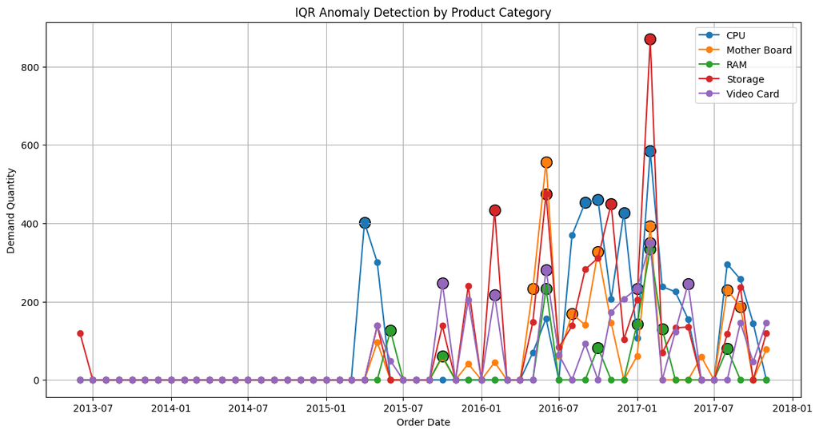

```python
plt.figure(figsize=(14, 7))                                              ## Visualize IQR Anomalies

for category in monthly["CategoryName"].unique():

    category_data = monthly[
        monthly["CategoryName"] == category
    ]

    plt.plot(
        category_data["OrderDate"],
        category_data["Quantity"],
        marker="o",
        label=category
    )

    anomaly_data = category_data[
        category_data["IQR_Anomaly"] == True
    ]

    plt.scatter(
        anomaly_data["OrderDate"],
        anomaly_data["Quantity"],
        s=130,
        edgecolor="black"
    )

plt.title(
    "IQR Anomaly Detection by Product Category"
)

plt.xlabel("Order Date")
plt.ylabel("Demand Quantity")

plt.legend()
plt.grid(True)

plt.savefig(
    "iqr_anomaly_detection.png",
    dpi=300,
    bbox_inches="tight"
)

plt.show()
```

```python
comparison = monthly[[                                                        ## Compare IQR with Z-Score
        "OrderDate",
        "CategoryName",
        "Quantity",
        "ZScore",
        "ZScore_Anomaly",
        "IQR_Anomaly"
    ]].copy()
comparison.head(20)
```

|  | OrderDate | CategoryName | Quantity | ZScore | ZScore_Anomaly | IQR_Anomaly |
| --- | --- | --- | --- | --- | --- | --- |
| 0 | 2013-06-01 | CPU | 0.0 | -0.583121 | False | False |
| 1 | 2013-07-01 | CPU | 0.0 | -0.583121 | False | False |
| 2 | 2013-08-01 | CPU | 0.0 | -0.583121 | False | False |
| 3 | 2013-09-01 | CPU | 0.0 | -0.583121 | False | False |
| 4 | 2013-10-01 | CPU | 0.0 | -0.583121 | False | False |
| 5 | 2013-11-01 | CPU | 0.0 | -0.583121 | False | False |
| 6 | 2013-12-01 | CPU | 0.0 | -0.583121 | False | False |
| 7 | 2014-01-01 | CPU | 0.0 | -0.583121 | False | False |
| 8 | 2014-02-01 | CPU | 0.0 | -0.583121 | False | False |
| 9 | 2014-03-01 | CPU | 0.0 | -0.583121 | False | False |
| 10 | 2014-04-01 | CPU | 0.0 | -0.583121 | False | False |
| 11 | 2014-05-01 | CPU | 0.0 | -0.583121 | False | False |
| 12 | 2014-06-01 | CPU | 0.0 | -0.583121 | False | False |
| 13 | 2014-07-01 | CPU | 0.0 | -0.583121 | False | False |
| 14 | 2014-08-01 | CPU | 0.0 | -0.583121 | False | False |
| 15 | 2014-09-01 | CPU | 0.0 | -0.583121 | False | False |
| 16 | 2014-10-01 | CPU | 0.0 | -0.583121 | False | False |
| 17 | 2014-11-01 | CPU | 0.0 | -0.583121 | False | False |
| 18 | 2014-12-01 | CPU | 0.0 | -0.583121 | False | False |
| 19 | 2015-01-01 | CPU | 0.0 | -0.583121 | False | False |

```python
comparison_summary = pd.DataFrame({"Method": ["Z-Score","IQR"],                                 ## Create an Overall Comparison Summary
    "Total_Anomalies": [monthly["ZScore_Anomaly"].sum(), monthly["IQR_Anomaly"].sum()]})
comparison_summary
```

|  | Method | Total_Anomalies |
| --- | --- | --- |
| 0 | Z-Score | 7 |
| 1 | IQR | 30 |

```python
both_anomalies = monthly[(monthly["ZScore_Anomaly"] == True) & (monthly["IQR_Anomaly"] == True)]    ## Find Anomalies Detected by Both Methods
both_anomalies[
    [
        "OrderDate",
        "CategoryName",
        "Quantity",
        "ZScore"
    ]
]
```

|  | OrderDate | CategoryName | Quantity | ZScore |
| --- | --- | --- | --- | --- |
| 44 | 2017-02-01 | CPU | 584.0 | 3.207708 |
| 90 | 2016-06-01 | Mother Board | 557.0 | 4.546087 |
| 98 | 2017-02-01 | Mother Board | 393.0 | 3.065825 |
| 144 | 2016-06-01 | RAM | 233.0 | 3.385367 |
| 152 | 2017-02-01 | RAM | 334.0 | 5.005993 |
| 206 | 2017-02-01 | Storage | 870.0 | 4.783234 |
| 260 | 2017-02-01 | Video Card | 351.0 | 3.171341 |

```python
print("Anomalies detected by both methods:",len(both_anomalies))
```

```
Anomalies detected by both methods: 7
```

```python
category_comparison = (monthly.groupby("CategoryName").agg(                  ## Create Category-Wise Comparison
        ZScore_Anomalies=("ZScore_Anomaly", "sum"),
        IQR_Anomalies=("IQR_Anomaly", "sum")).reset_index())
category_comparison
```

|  | CategoryName | ZScore_Anomalies | IQR_Anomalies |
| --- | --- | --- | --- |
| 0 | CPU | 1 | 5 |
| 1 | Mother Board | 2 | 7 |
| 2 | RAM | 2 | 8 |
| 3 | Storage | 1 | 4 |
| 4 | Video Card | 1 | 6 |

```python
monthly.to_csv("iqr_anomaly_results.csv",index=False)         ## save complete updated file
```

```python
iqr_anomalies.to_csv("iqr_detected_anomalies.csv",index=False)
```

```python
comparison_summary.to_csv("zscore_iqr_comparison.csv",index=False)
```

```python
category_comparison.to_csv("category_anomaly_comparison.csv",index=False)
```

## IQR vs Z-Score Analysis

The IQR method detected 30 anomalies, while the Z-Score method detected 7 anomalies.

7 anomalies were identified by both methods.

The difference occurs because Z-Score measures observations using the mean and standard deviation, whereas IQR identifies values outside the lower and upper quartile-based boundaries.

These detected observations represent unusual demand patterns that require further business investigation before determining their actual cause.

## Isolation Forest + comparison of all three methods

```python
monthly = pd.read_csv("iqr_anomaly_results.csv",parse_dates=["OrderDate"])         ## Check Previous Work
```

```python
from sklearn.ensemble import IsolationForest                                   ## Import Isolation Forest
```

```python
monthly["IF_Anomaly"] = False                                                   ## Create the Isolation Forest Result Column
monthly.head()
```

|  | OrderDate | CategoryName | Quantity | ZScore | ZScore_Anomaly | IQR_Lower | IQR_Upper | IQR_Anomaly | IF_Anomaly |
| --- | --- | --- | --- | --- | --- | --- | --- | --- | --- |
| 0 | 2013-06-01 | CPU | 0.0 | -0.583121 | False | -228.75 | 381.25 | False | False |
| 1 | 2013-07-01 | CPU | 0.0 | -0.583121 | False | -228.75 | 381.25 | False | False |
| 2 | 2013-08-01 | CPU | 0.0 | -0.583121 | False | -228.75 | 381.25 | False | False |
| 3 | 2013-09-01 | CPU | 0.0 | -0.583121 | False | -228.75 | 381.25 | False | False |
| 4 | 2013-10-01 | CPU | 0.0 | -0.583121 | False | -228.75 | 381.25 | False | False |

```python
for category in monthly["CategoryName"].unique():                         ## Apply Isolation Forest Category-Wise

    mask = monthly["CategoryName"] == category

    category_data = monthly.loc[mask, ["Quantity"]].dropna()

    model = IsolationForest(
        contamination=0.05,
        random_state=42)

    predictions = model.fit_predict(
        category_data[["Quantity"]])

    monthly.loc[category_data.index,"IF_Anomaly"] = predictions == -1
```

```python
monthly[[                                                               ## Check Isolation Forest Results
        "OrderDate",
        "CategoryName",
        "Quantity",
        "IF_Anomaly"]
].head(20)
```

|  | OrderDate | CategoryName | Quantity | IF_Anomaly |
| --- | --- | --- | --- | --- |
| 0 | 2013-06-01 | CPU | 0.0 | False |
| 1 | 2013-07-01 | CPU | 0.0 | False |
| 2 | 2013-08-01 | CPU | 0.0 | False |
| 3 | 2013-09-01 | CPU | 0.0 | False |
| 4 | 2013-10-01 | CPU | 0.0 | False |
| 5 | 2013-11-01 | CPU | 0.0 | False |
| 6 | 2013-12-01 | CPU | 0.0 | False |
| 7 | 2014-01-01 | CPU | 0.0 | False |
| 8 | 2014-02-01 | CPU | 0.0 | False |
| 9 | 2014-03-01 | CPU | 0.0 | False |
| 10 | 2014-04-01 | CPU | 0.0 | False |
| 11 | 2014-05-01 | CPU | 0.0 | False |
| 12 | 2014-06-01 | CPU | 0.0 | False |
| 13 | 2014-07-01 | CPU | 0.0 | False |
| 14 | 2014-08-01 | CPU | 0.0 | False |
| 15 | 2014-09-01 | CPU | 0.0 | False |
| 16 | 2014-10-01 | CPU | 0.0 | False |
| 17 | 2014-11-01 | CPU | 0.0 | False |
| 18 | 2014-12-01 | CPU | 0.0 | False |
| 19 | 2015-01-01 | CPU | 0.0 | False |

```python
if_anomalies = monthly[                                                   ## only detected anomalies
    monthly["IF_Anomaly"] == True]

if_anomalies[[
        "OrderDate",
        "CategoryName",
        "Quantity"]]
```

|  | OrderDate | CategoryName | Quantity |
| --- | --- | --- | --- |
| 35 | 2016-05-01 | CPU | 70.0 |
| 43 | 2017-01-01 | CPU | 107.0 |
| 44 | 2017-02-01 | CPU | 584.0 |
| 90 | 2016-06-01 | Mother Board | 557.0 |
| 94 | 2016-10-01 | Mother Board | 327.0 |
| 98 | 2017-02-01 | Mother Board | 393.0 |
| 136 | 2015-10-01 | RAM | 61.0 |
| 144 | 2016-06-01 | RAM | 233.0 |
| 152 | 2017-02-01 | RAM | 334.0 |
| 194 | 2016-02-01 | Storage | 434.0 |
| 198 | 2016-06-01 | Storage | 474.0 |
| 206 | 2017-02-01 | Storage | 870.0 |
| 252 | 2016-06-01 | Video Card | 281.0 |
| 255 | 2016-09-01 | Video Card | 92.0 |
| 260 | 2017-02-01 | Video Card | 351.0 |

```python
print("Total Isolation Forest anomalies:",monthly["IF_Anomaly"].sum())                      ## Count Total Isolation Forest Anomalies
```

```
Total Isolation Forest anomalies: 15
```

```python
if_counts = (monthly.groupby("CategoryName")["IF_Anomaly"].sum())                            ## Count Anomalies by Category
if_counts
```

```
CategoryName
CPU             3
Mother Board    3
RAM             3
Storage         3
Video Card      3
Name: IF_Anomaly, dtype: int64
```

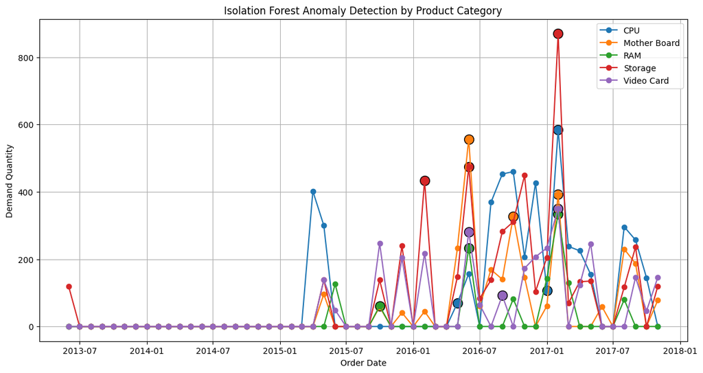

```python
 plt.figure(figsize=(14, 7))                                                    ## Visualize Isolation Forest Anomalies

for category in monthly["CategoryName"].unique():

    category_data = monthly[
        monthly["CategoryName"] == category
    ]

    plt.plot(
        category_data["OrderDate"],
        category_data["Quantity"],
        marker="o",
        label=category
    )

    anomaly_data = category_data[
        category_data["IF_Anomaly"] == True
    ]

    plt.scatter(
        anomaly_data["OrderDate"],
        anomaly_data["Quantity"],
        s=130,
        edgecolor="black"
    )

plt.title(
    "Isolation Forest Anomaly Detection by Product Category"
)

plt.xlabel("Order Date")
plt.ylabel("Demand Quantity")

plt.legend()
plt.grid(True)

plt.savefig(
    r"C:\Users\raksh\OneDrive\Desktop\Infotect Project 2026\isolation_forest_anomalies.png",
    dpi=300,
    bbox_inches="tight"
)

plt.show()
```

```python
three_method_comparison = monthly[                               ## Compare All Three Methods
    [
        "OrderDate",
        "CategoryName",
        "Quantity",
        "ZScore_Anomaly",
        "IQR_Anomaly",
        "IF_Anomaly"
    ]
].copy()

three_method_comparison.head(20)
```

|  | OrderDate | CategoryName | Quantity | ZScore_Anomaly | IQR_Anomaly | IF_Anomaly |
| --- | --- | --- | --- | --- | --- | --- |
| 0 | 2013-06-01 | CPU | 0.0 | False | False | False |
| 1 | 2013-07-01 | CPU | 0.0 | False | False | False |
| 2 | 2013-08-01 | CPU | 0.0 | False | False | False |
| 3 | 2013-09-01 | CPU | 0.0 | False | False | False |
| 4 | 2013-10-01 | CPU | 0.0 | False | False | False |
| 5 | 2013-11-01 | CPU | 0.0 | False | False | False |
| 6 | 2013-12-01 | CPU | 0.0 | False | False | False |
| 7 | 2014-01-01 | CPU | 0.0 | False | False | False |
| 8 | 2014-02-01 | CPU | 0.0 | False | False | False |
| 9 | 2014-03-01 | CPU | 0.0 | False | False | False |
| 10 | 2014-04-01 | CPU | 0.0 | False | False | False |
| 11 | 2014-05-01 | CPU | 0.0 | False | False | False |
| 12 | 2014-06-01 | CPU | 0.0 | False | False | False |
| 13 | 2014-07-01 | CPU | 0.0 | False | False | False |
| 14 | 2014-08-01 | CPU | 0.0 | False | False | False |
| 15 | 2014-09-01 | CPU | 0.0 | False | False | False |
| 16 | 2014-10-01 | CPU | 0.0 | False | False | False |
| 17 | 2014-11-01 | CPU | 0.0 | False | False | False |
| 18 | 2014-12-01 | CPU | 0.0 | False | False | False |
| 19 | 2015-01-01 | CPU | 0.0 | False | False | False |

```python
method_summary = pd.DataFrame({                                    ## Compare Total Anomalies
    "Method": [
        "Z-Score",
        "IQR",
        "Isolation Forest"
    ],

    "Total_Anomalies": [
        int(monthly["ZScore_Anomaly"].sum()),
        int(monthly["IQR_Anomaly"].sum()),
        int(monthly["IF_Anomaly"].sum())
    ]
})

method_summary
```

|  | Method | Total_Anomalies |
| --- | --- | --- |
| 0 | Z-Score | 7 |
| 1 | IQR | 30 |
| 2 | Isolation Forest | 15 |

```python
category_method_comparison = (                                        ## Compare Methods Category-Wise
    monthly
    .groupby("CategoryName")
    .agg(
        ZScore_Anomalies=(
            "ZScore_Anomaly",
            "sum"
        ),

        IQR_Anomalies=(
            "IQR_Anomaly",
            "sum"
        ),

        IsolationForest_Anomalies=(
            "IF_Anomaly",
            "sum"
        )
    )
    .reset_index()
)

category_method_comparison
```

|  | CategoryName | ZScore_Anomalies | IQR_Anomalies | IsolationForest_Anomalies |
| --- | --- | --- | --- | --- |
| 0 | CPU | 1 | 5 | 3 |
| 1 | Mother Board | 2 | 7 | 3 |
| 2 | RAM | 2 | 8 | 3 |
| 3 | Storage | 1 | 4 | 3 |
| 4 | Video Card | 1 | 6 | 3 |

```python
all_three = monthly[                                  ## Find Anomalies Detected by All Three Methods
    (monthly["ZScore_Anomaly"] == True) &
    (monthly["IQR_Anomaly"] == True) &
    (monthly["IF_Anomaly"] == True)
]

all_three[
    [
        "OrderDate",
        "CategoryName",
        "Quantity",
        "ZScore"
    ]
]
```

|  | OrderDate | CategoryName | Quantity | ZScore |
| --- | --- | --- | --- | --- |
| 44 | 2017-02-01 | CPU | 584.0 | 3.207708 |
| 90 | 2016-06-01 | Mother Board | 557.0 | 4.546087 |
| 98 | 2017-02-01 | Mother Board | 393.0 | 3.065825 |
| 144 | 2016-06-01 | RAM | 233.0 | 3.385367 |
| 152 | 2017-02-01 | RAM | 334.0 | 5.005993 |
| 206 | 2017-02-01 | Storage | 870.0 | 4.783234 |
| 260 | 2017-02-01 | Video Card | 351.0 | 3.171341 |

```python
print("Anomalies detected by all 3 methods:",len(all_three))
```

```
Anomalies detected by all 3 methods: 7
```

```python
monthly["Anomaly_Method_Count"] = (                                    ## Find Anomalies Detected by At Least Two Methods
    monthly["ZScore_Anomaly"].astype(int) +
    monthly["IQR_Anomaly"].astype(int) +
    monthly["IF_Anomaly"].astype(int)
)
```

```python
high_confidence_anomalies = monthly[
    monthly["Anomaly_Method_Count"] >= 2
]

high_confidence_anomalies[
    [
        "OrderDate",
        "CategoryName",
        "Quantity",
        "ZScore_Anomaly",
        "IQR_Anomaly",
        "IF_Anomaly",
        "Anomaly_Method_Count"
    ]
]
```

|  | OrderDate | CategoryName | Quantity | ZScore_Anomaly | IQR_Anomaly | IF_Anomaly | Anomaly_Method_Count |
| --- | --- | --- | --- | --- | --- | --- | --- |
| 44 | 2017-02-01 | CPU | 584.0 | True | True | True | 3 |
| 90 | 2016-06-01 | Mother Board | 557.0 | True | True | True | 3 |
| 94 | 2016-10-01 | Mother Board | 327.0 | False | True | True | 2 |
| 98 | 2017-02-01 | Mother Board | 393.0 | True | True | True | 3 |
| 136 | 2015-10-01 | RAM | 61.0 | False | True | True | 2 |
| 144 | 2016-06-01 | RAM | 233.0 | True | True | True | 3 |
| 152 | 2017-02-01 | RAM | 334.0 | True | True | True | 3 |
| 194 | 2016-02-01 | Storage | 434.0 | False | True | True | 2 |
| 198 | 2016-06-01 | Storage | 474.0 | False | True | True | 2 |
| 206 | 2017-02-01 | Storage | 870.0 | True | True | True | 3 |
| 252 | 2016-06-01 | Video Card | 281.0 | False | True | True | 2 |
| 260 | 2017-02-01 | Video Card | 351.0 | True | True | True | 3 |

```python
monthly["Final_Anomaly"] = (monthly["Anomaly_Method_Count"] >= 2)                                     ## Create a Final Anomaly Flag
```

```python
monthly[
    [
        "OrderDate",
        "CategoryName",
        "Quantity",
        "Anomaly_Method_Count",
        "Final_Anomaly"
    ]
].head()
```

|  | OrderDate | CategoryName | Quantity | Anomaly_Method_Count | Final_Anomaly |
| --- | --- | --- | --- | --- | --- |
| 0 | 2013-06-01 | CPU | 0.0 | 0 | False |
| 1 | 2013-07-01 | CPU | 0.0 | 0 | False |
| 2 | 2013-08-01 | CPU | 0.0 | 0 | False |
| 3 | 2013-09-01 | CPU | 0.0 | 0 | False |
| 4 | 2013-10-01 | CPU | 0.0 | 0 | False |

```python
monthly.to_csv(
    r"C:\Users\raksh\OneDrive\Desktop\Infotect Project 2026\final_anomaly_results.csv",
    index=False
)
```

```python
if_anomalies.to_csv(
    r"C:\Users\raksh\OneDrive\Desktop\Infotect Project 2026\isolation_forest_anomalies.csv",
    index=False
)
```

```python
high_confidence_anomalies.to_csv(
    r"C:\Users\raksh\OneDrive\Desktop\Infotect Project 2026\high_confidence_anomalies.csv",
    index=False
)
```

```python
method_summary.to_csv(
    r"C:\Users\raksh\OneDrive\Desktop\Infotect Project 2026\anomaly_method_summary.csv",
    index=False
)
```

```python
category_method_comparison.to_csv(
    r"C:\Users\raksh\OneDrive\Desktop\Infotect Project 2026\category_method_comparison.csv",
    index=False
)
```

### Comparison of Anomaly Detection Methods

Three anomaly detection methods were evaluated: Z-Score, IQR, and Isolation Forest.

Z-Score identifies extreme observations based on the mean and standard deviation, while IQR detects values outside quartile-based boundaries. Isolation Forest uses a machine-learning approach to identify observations that are easier to isolate from normal demand.

The results from all three methods were compared category-wise. Observations detected by at least two methods were prioritized as higher-confidence anomaly candidates. This combined approach can help reduce unnecessary alerts while highlighting unusual demand patterns that require business investigation.

Z-Score detected: 7 anomalies

IQR detected: 30 anomalies

Isolation Forest detected: 15 anomalies

Detected by all three methods: 7 anomalies

```python
monthly.columns.tolist()                        ## Verify Your Main Dataset
```

```
['OrderDate',
 'CategoryName',
 'Quantity',
 'ZScore',
 'ZScore_Anomaly',
 'IQR_Lower',
 'IQR_Upper',
 'IQR_Anomaly',
 'IF_Anomaly',
 'Anomaly_Method_Count',
 'Final_Anomaly']
```

```python
monthly.isnull().sum()
```

```
OrderDate               0
CategoryName            0
Quantity                0
ZScore                  0
ZScore_Anomaly          0
IQR_Lower               0
IQR_Upper               0
IQR_Anomaly             0
IF_Anomaly              0
Anomaly_Method_Count    0
Final_Anomaly           0
dtype: int64
```

```python
monthly.duplicated(subset=["OrderDate", "CategoryName"]).sum()
```

```
np.int64(0)
```

```python
monthly["Anomaly_Method_Count"] = (                               ## Recalculate the Method Agreement
    monthly["ZScore_Anomaly"].astype(int)
    + monthly["IQR_Anomaly"].astype(int)
    + monthly["IF_Anomaly"].astype(int)
)
```

```python
monthly[
    [
        "OrderDate",
        "CategoryName",
        "Quantity",
        "ZScore_Anomaly",
        "IQR_Anomaly",
        "IF_Anomaly",
        "Anomaly_Method_Count"
    ]
].head(20)
```

|  | OrderDate | CategoryName | Quantity | ZScore_Anomaly | IQR_Anomaly | IF_Anomaly | Anomaly_Method_Count |
| --- | --- | --- | --- | --- | --- | --- | --- |
| 0 | 2013-06-01 | CPU | 0.0 | False | False | False | 0 |
| 1 | 2013-07-01 | CPU | 0.0 | False | False | False | 0 |
| 2 | 2013-08-01 | CPU | 0.0 | False | False | False | 0 |
| 3 | 2013-09-01 | CPU | 0.0 | False | False | False | 0 |
| 4 | 2013-10-01 | CPU | 0.0 | False | False | False | 0 |
| 5 | 2013-11-01 | CPU | 0.0 | False | False | False | 0 |
| 6 | 2013-12-01 | CPU | 0.0 | False | False | False | 0 |
| 7 | 2014-01-01 | CPU | 0.0 | False | False | False | 0 |
| 8 | 2014-02-01 | CPU | 0.0 | False | False | False | 0 |
| 9 | 2014-03-01 | CPU | 0.0 | False | False | False | 0 |
| 10 | 2014-04-01 | CPU | 0.0 | False | False | False | 0 |
| 11 | 2014-05-01 | CPU | 0.0 | False | False | False | 0 |
| 12 | 2014-06-01 | CPU | 0.0 | False | False | False | 0 |
| 13 | 2014-07-01 | CPU | 0.0 | False | False | False | 0 |
| 14 | 2014-08-01 | CPU | 0.0 | False | False | False | 0 |
| 15 | 2014-09-01 | CPU | 0.0 | False | False | False | 0 |
| 16 | 2014-10-01 | CPU | 0.0 | False | False | False | 0 |
| 17 | 2014-11-01 | CPU | 0.0 | False | False | False | 0 |
| 18 | 2014-12-01 | CPU | 0.0 | False | False | False | 0 |
| 19 | 2015-01-01 | CPU | 0.0 | False | False | False | 0 |

```python
monthly["Final_Anomaly"] = (monthly["Anomaly_Method_Count"] >= 2)               ## Create the Final Anomaly Flag
```

```python
monthly[
    [
        "OrderDate",
        "CategoryName",
        "Quantity",
        "Anomaly_Method_Count",
        "Final_Anomaly"
    ]
].head(20)
```

|  | OrderDate | CategoryName | Quantity | Anomaly_Method_Count | Final_Anomaly |
| --- | --- | --- | --- | --- | --- |
| 0 | 2013-06-01 | CPU | 0.0 | 0 | False |
| 1 | 2013-07-01 | CPU | 0.0 | 0 | False |
| 2 | 2013-08-01 | CPU | 0.0 | 0 | False |
| 3 | 2013-09-01 | CPU | 0.0 | 0 | False |
| 4 | 2013-10-01 | CPU | 0.0 | 0 | False |
| 5 | 2013-11-01 | CPU | 0.0 | 0 | False |
| 6 | 2013-12-01 | CPU | 0.0 | 0 | False |
| 7 | 2014-01-01 | CPU | 0.0 | 0 | False |
| 8 | 2014-02-01 | CPU | 0.0 | 0 | False |
| 9 | 2014-03-01 | CPU | 0.0 | 0 | False |
| 10 | 2014-04-01 | CPU | 0.0 | 0 | False |
| 11 | 2014-05-01 | CPU | 0.0 | 0 | False |
| 12 | 2014-06-01 | CPU | 0.0 | 0 | False |
| 13 | 2014-07-01 | CPU | 0.0 | 0 | False |
| 14 | 2014-08-01 | CPU | 0.0 | 0 | False |
| 15 | 2014-09-01 | CPU | 0.0 | 0 | False |
| 16 | 2014-10-01 | CPU | 0.0 | 0 | False |
| 17 | 2014-11-01 | CPU | 0.0 | 0 | False |
| 18 | 2014-12-01 | CPU | 0.0 | 0 | False |
| 19 | 2015-01-01 | CPU | 0.0 | 0 | False |

```python
final_anomaly_dataset = monthly[                             ## Create the Final Anomaly Dataset
    [
        "OrderDate",
        "CategoryName",
        "Quantity",
        "ZScore",
        "ZScore_Anomaly",
        "IQR_Lower",
        "IQR_Upper",
        "IQR_Anomaly",
        "IF_Anomaly",
        "Anomaly_Method_Count",
        "Final_Anomaly"
    ]
].copy()
```

```python
final_anomaly_dataset.head()
```

|  | OrderDate | CategoryName | Quantity | ZScore | ZScore_Anomaly | IQR_Lower | IQR_Upper | IQR_Anomaly | IF_Anomaly | Anomaly_Method_Count | Final_Anomaly |
| --- | --- | --- | --- | --- | --- | --- | --- | --- | --- | --- | --- |
| 0 | 2013-06-01 | CPU | 0.0 | -0.583121 | False | -228.75 | 381.25 | False | False | 0 | False |
| 1 | 2013-07-01 | CPU | 0.0 | -0.583121 | False | -228.75 | 381.25 | False | False | 0 | False |
| 2 | 2013-08-01 | CPU | 0.0 | -0.583121 | False | -228.75 | 381.25 | False | False | 0 | False |
| 3 | 2013-09-01 | CPU | 0.0 | -0.583121 | False | -228.75 | 381.25 | False | False | 0 | False |
| 4 | 2013-10-01 | CPU | 0.0 | -0.583121 | False | -228.75 | 381.25 | False | False | 0 | False |

```python
final_anomaly_dataset.info()
```

```
<class 'pandas.core.frame.DataFrame'>
RangeIndex: 270 entries, 0 to 269
Data columns (total 11 columns):
 #   Column                Non-Null Count  Dtype
---  ------                --------------  -----
 0   OrderDate             270 non-null    datetime64[ns]
 1   CategoryName          270 non-null    object
 2   Quantity              270 non-null    float64
 3   ZScore                270 non-null    float64
 4   ZScore_Anomaly        270 non-null    bool
 5   IQR_Lower             270 non-null    float64
 6   IQR_Upper             270 non-null    float64
 7   IQR_Anomaly           270 non-null    bool
 8   IF_Anomaly            270 non-null    bool
 9   Anomaly_Method_Count  270 non-null    int64
 10  Final_Anomaly         270 non-null    bool
dtypes: bool(4), datetime64[ns](1), float64(4), int64(1), object(1)
memory usage: 15.9+ KB
```

```python
final_anomalies = final_anomaly_dataset[final_anomaly_dataset["Final_Anomaly"] == True]          ## Display Only Final Anomalies
final_anomalies
```

|  | OrderDate | CategoryName | Quantity | ZScore | ZScore_Anomaly | IQR_Lower | IQR_Upper | IQR_Anomaly | IF_Anomaly | Anomaly_Method_Count | Final_Anomaly |
| --- | --- | --- | --- | --- | --- | --- | --- | --- | --- | --- | --- |
| 44 | 2017-02-01 | CPU | 584.0 | 3.207708 | True | -228.750 | 381.250 | True | True | 3 | True |
| 90 | 2016-06-01 | Mother Board | 557.0 | 4.546087 | True | -88.125 | 146.875 | True | True | 3 | True |
| 94 | 2016-10-01 | Mother Board | 327.0 | 2.470111 | False | -88.125 | 146.875 | True | True | 2 | True |
| 98 | 2017-02-01 | Mother Board | 393.0 | 3.065825 | True | -88.125 | 146.875 | True | True | 3 | True |
| 136 | 2015-10-01 | RAM | 61.0 | 0.625489 | False | 0.000 | 0.000 | True | True | 2 | True |
| 144 | 2016-06-01 | RAM | 233.0 | 3.385367 | True | 0.000 | 0.000 | True | True | 3 | True |
| 152 | 2017-02-01 | RAM | 334.0 | 5.005993 | True | 0.000 | 0.000 | True | True | 3 | True |
| 194 | 2016-02-01 | Storage | 434.0 | 2.104250 | False | -201.750 | 336.250 | True | True | 2 | True |
| 198 | 2016-06-01 | Storage | 474.0 | 2.350028 | False | -201.750 | 336.250 | True | True | 2 | True |
| 206 | 2017-02-01 | Storage | 870.0 | 4.783234 | True | -201.750 | 336.250 | True | True | 3 | True |
| 252 | 2016-06-01 | Video Card | 281.0 | 2.421643 | False | -127.875 | 213.125 | True | True | 2 | True |
| 260 | 2017-02-01 | Video Card | 351.0 | 3.171341 | True | -127.875 | 213.125 | True | True | 3 | True |

```python
print("Total final anomalies:",len(final_anomalies))               ## count
```

```
Total final anomalies: 12
```

```python
final_anomalies["CategoryName"].value_counts()                 ## heck by category
```

```
CategoryName
Mother Board    3
Storage         3
RAM             3
Video Card      2
CPU             1
Name: count, dtype: int64
```

```python
anomaly_summary = (                                    ## Create anomaly_summary.csv
    monthly
    .groupby("CategoryName")
    .agg(
        Total_Records=("Quantity", "count"),
        Average_Demand=("Quantity", "mean"),
        Maximum_Demand=("Quantity", "max"),
        ZScore_Anomalies=("ZScore_Anomaly", "sum"),
        IQR_Anomalies=("IQR_Anomaly", "sum"),
        IsolationForest_Anomalies=("IF_Anomaly", "sum"),
        Final_Anomalies=("Final_Anomaly", "sum")
    )
    .reset_index()
)
```

```python
anomaly_summary["Average_Demand"] = (anomaly_summary["Average_Demand"].round(2))   ## Round the average
anomaly_summary
```

|  | CategoryName | Total_Records | Average_Demand | Maximum_Demand | ZScore_Anomalies | IQR_Anomalies | IsolationForest_Anomalies | Final_Anomalies |
| --- | --- | --- | --- | --- | --- | --- | --- | --- |
| 0 | CPU | 54 | 89.83 | 584.0 | 1 | 5 | 3 | 1 |
| 1 | Mother Board | 54 | 53.33 | 557.0 | 2 | 7 | 3 | 3 |
| 2 | RAM | 54 | 22.02 | 334.0 | 2 | 8 | 3 | 3 |
| 3 | Storage | 54 | 91.54 | 870.0 | 1 | 4 | 3 | 3 |
| 4 | Video Card | 54 | 54.89 | 351.0 | 1 | 6 | 3 | 2 |

```python
method_summary = pd.DataFrame({                     ## Create Overall Method Summary
    "Method": [
        "Z-Score",
        "IQR",
        "Isolation Forest",
        "Final Multi-Method Rule"
    ],

    "Total_Anomalies": [
        int(monthly["ZScore_Anomaly"].sum()),
        int(monthly["IQR_Anomaly"].sum()),
        int(monthly["IF_Anomaly"].sum()),
        int(monthly["Final_Anomaly"].sum())
    ]
})

method_summary
```

|  | Method | Total_Anomalies |
| --- | --- | --- |
| 0 | Z-Score | 7 |
| 1 | IQR | 30 |
| 2 | Isolation Forest | 15 |
| 3 | Final Multi-Method Rule | 12 |

```python
final_anomaly_dataset.to_csv(r"C:\Users\raksh\OneDrive\Desktop\Infotect Project 2026\final_anomaly_dataset.csv",index=False)
```

```python
anomaly_summary.to_csv(r"C:\Users\raksh\OneDrive\Desktop\Infotect Project 2026\anomaly_summary.csv",index=False)
```

```python
final_anomalies.to_csv(r"C:\Users\raksh\OneDrive\Desktop\Infotect Project 2026\final_detected_anomalies.csv",index=False)
```

```python
method_summary.to_csv(r"C:\Users\raksh\OneDrive\Desktop\Infotect Project 2026\anomaly_method_summary.csv",index=False)
```

```python
final_check = pd.read_csv("final_anomaly_dataset.csv")             ## Validate the Saved Files
summary_check = pd.read_csv("anomaly_summary.csv")
```

```python
final_check.head()
```

|  | OrderDate | CategoryName | Quantity | ZScore | ZScore_Anomaly | IQR_Lower | IQR_Upper | IQR_Anomaly | IF_Anomaly | Anomaly_Method_Count | Final_Anomaly |
| --- | --- | --- | --- | --- | --- | --- | --- | --- | --- | --- | --- |
| 0 | 2013-06-01 | CPU | 0.0 | -0.583121 | False | -228.75 | 381.25 | False | False | 0 | False |
| 1 | 2013-07-01 | CPU | 0.0 | -0.583121 | False | -228.75 | 381.25 | False | False | 0 | False |
| 2 | 2013-08-01 | CPU | 0.0 | -0.583121 | False | -228.75 | 381.25 | False | False | 0 | False |
| 3 | 2013-09-01 | CPU | 0.0 | -0.583121 | False | -228.75 | 381.25 | False | False | 0 | False |
| 4 | 2013-10-01 | CPU | 0.0 | -0.583121 | False | -228.75 | 381.25 | False | False | 0 | False |

```python
summary_check
```

|  | CategoryName | Total_Records | Average_Demand | Maximum_Demand | ZScore_Anomalies | IQR_Anomalies | IsolationForest_Anomalies | Final_Anomalies |
| --- | --- | --- | --- | --- | --- | --- | --- | --- |
| 0 | CPU | 54 | 89.83 | 584.0 | 1 | 5 | 3 | 1 |
| 1 | Mother Board | 54 | 53.33 | 557.0 | 2 | 7 | 3 | 3 |
| 2 | RAM | 54 | 22.02 | 334.0 | 2 | 8 | 3 | 3 |
| 3 | Storage | 54 | 91.54 | 870.0 | 1 | 4 | 3 | 3 |
| 4 | Video Card | 54 | 54.89 | 351.0 | 1 | 6 | 3 | 2 |

```python
print("Final dataset shape:",final_check.shape)
print("Summary shape:",summary_check.shape)
```

```
Final dataset shape: (270, 11)
Summary shape: (5, 8)
```

```python
final_check.isnull().sum()
```

```
OrderDate               0
CategoryName            0
Quantity                0
ZScore                  0
ZScore_Anomaly          0
IQR_Lower               0
IQR_Upper               0
IQR_Anomaly             0
IF_Anomaly              0
Anomaly_Method_Count    0
Final_Anomaly           0
dtype: int64
```